# Maryland Lake Buffers

Michael Allman

5/19/2021

### Introduction

The goal of this project was to examine the extent to which Maryland lakes are adequately buffered by vegetation. In addition I wanted to compare the extent of buffering to the percent the population working in agriculture to see what patterns would arise. This script downloads data and performs several transformations before exporting the results into QGIS, where the final analysis will be conducted.

## Downloading data

I have downloaded shapefiles of Maryland canopy, streams, and lakes separately. These all can be found at [Maryland.gov](https://data.imap.maryland.gov/).

```r
# Download total occupation and agricultural worker ACS 2019 Census data from https://www.socialexplorer.com/data/ACS2019_5yr/metadata/?ds=ACS19_5yr for Maryland.
MD_agri = get_acs(geography = "county",
      variables = c("total_occ" = "C24010_001",# Total working population above 16.
                    "agri_female" = "C24010_067", # Female agricultural workers
                     "agri_male" =  "C24010_031"), # Male agricultural workers
                          year = 2019,
survey = "acs5",
state = c(24),  # FIPS code for Maryland
geometry = TRUE,
output = "wide")
# Compute the percent of the working population in agriculture.
MD_agri$agri_percent = (((MD_agri$agri_femaleE +  MD_agri$agri_maleE) / MD_agri$total_occE)*100)

# Create a sf object.
st_as_sf(MD_agri)
```

```
## Simple feature collection with 24 features and 9 fields
## geometry type:  MULTIPOLYGON
## dimension:      XY
## bbox:           xmin: -79.48765 ymin: 37.91172 xmax: -75.04894 ymax: 39.72304
## geographic CRS: NAD83
## First 10 features:
##    GEOID                             NAME total_occE total_occM agri_femaleE
## 1  24035    Queen Anne's County, Maryland      25558        516           51
## 2  24005       Baltimore County, Maryland     422955       2600          217
## 3  24003    Anne Arundel County, Maryland     292548       2138          124
## 4  24013         Carroll County, Maryland      87632        974          111
## 5  24021       Frederick County, Maryland     134149       1209           79
## 6  24039        Somerset County, Maryland       8888        780           31
## 7  24029            Kent County, Maryland       9304        358           50
## 8  24047       Worcester County, Maryland      24144        607           28
```

[output cut: 24 more lines]

I’ll now define the data I already downloaded and make sure they’re all in the same projection before performing any analysis.

```r
MD_lakes = st_read("C:/Users/micha/Documents/GES_486/Final/Data_Final/Maryland_Waterbodies_Lakes_Detailed", "Maryland_Waterbodies_-_Lakes_(Detailed)")
MD_streams = st_read("C:/Users/micha/Documents/GES_486/Final/Data_Final/Maryland_Waterbodies_Streams", "HYDR_RiversStreamsDetailed_SHA")
```

Now to reproject to an equal area projection because area will be important. In this case I use EPSG: 5070.

```r
MD_agri = st_transform(MD_agri, crs = 5070)

MD_lakes = st_transform(MD_lakes, crs = 5070)

MD_streams = st_transform(MD_streams, crs = 5070)
```

Several following steps of the project will be done in GQIS. Transformations will include creating buffers for the lakes and streams and then calculating the percent of that area which actually meets the standards set by Maryland legislation. According to [the Maryland Department of Natural Resources](https://dnr.maryland.gov/forests/Pages/programapps/ripfbi.aspx#:~:text=Buffer%20widths%20of%2050%2D100,quality%20and%20fish%20habitat%20improvement) the appropriate width of forested buffers is 50 to 100 feet. For the purposes of this project streams, being numerous and small, will be given the low end of 50 foot buffers while lakes will have 100 foot buffers. Due to time constraints, only the percent of adequately buffered lake area will be calculated.

```r
st_write(MD_lakes, "C:/Users/micha/Documents/GES_486/Final/MD_lakes.shp")
st_write(MD_streams, "C:/Users/micha/Documents/GES_486/Final/MD_streams.shp")
```

### Joining QGIS Findings and Bivariate Classes

Having done some analysis in QGIS, it’s time to integrate the census data. I created a new layer of polygons that represent areas of less than 10% vegetation within Maryland lake buffer zones. I then used the field calculator to find out the total area of non-vegetated lake buffer perimeter and then the total buffer area for each Maryland county. Dividing the former by the latter gave me the percent area of lake perimeters that aren’t adequately buffered per county. This section will be creating bivariate classes to express a comparison between agriculture and adequately buffered lakes.

```r
# I wrote the new data down on a csv file. I'll have to read that file in and then use an appropriate join to merge it with the MD_agri file.

MD_per_buffered = read_csv("C:/Users/micha/Documents/GES_486/Final/Data_Final/MD_Buffer_Percents.csv")
MD_agri_buffer = left_join(MD_agri, MD_per_buffered,
                              by = "NAME")
```

Now I’ll create a new field for the bivariate classes and choose the method of classification based on what looks to best represent the data.

```r
library(biscale)
# Create classes
MD_agri_buffer = bi_class(MD_agri_buffer, x = agri_percent, y = PER_VEG, style = "quantile", dim = 3)
```

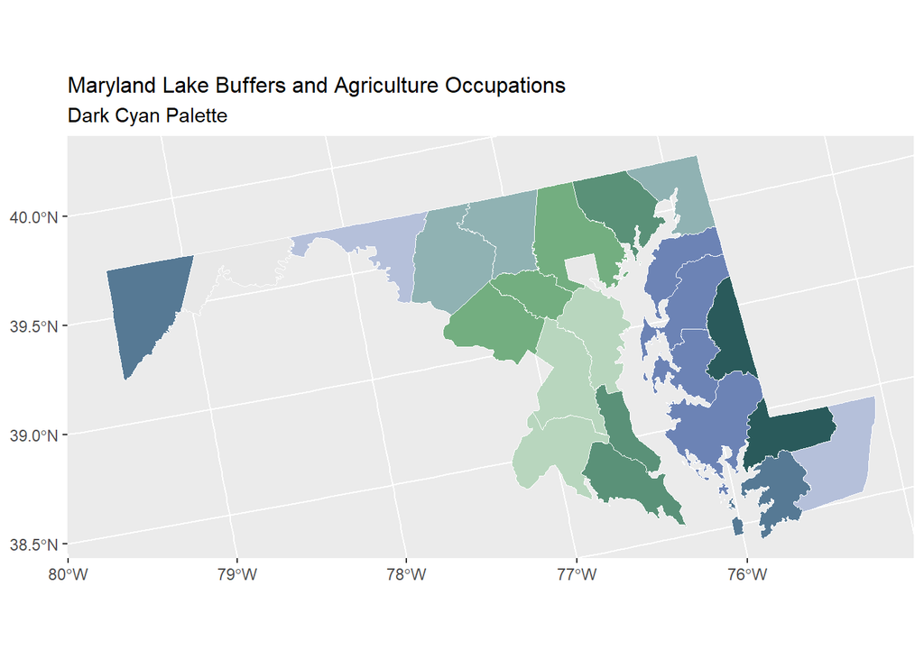

```r
plot(MD_bivariate)
```

```r
st_write(MD_agri_buffer, "C:/Users/micha/Documents/GES_486/Final/Bin_Final/MD_agri_buffer.shp")
```